# Communication Research Methods in Times of Hybrid War

SSK001F: The emerging field of strategic communication  
– in times of geopolitical conflict and crisis. 5 ECTS, VT25

nils.holmberg@iko.lu.se

## Presentation round

- Nils Holmberg
- Digital Marketing
- Computational  
  content analysis
- Cognitive  
  communication effects

[video not shown]

## Lecture lab overview

- Hybrid war concept
- Weaponized communications
- Targeting, attribution
- Detection, indicators
- Content features, NLP, CV
- Computational content analysis
- `CCA lab session + Break`
- Network analysis, HBMs
- Psychological defence, PDRI
- Counteraction measures
- Disinformation inoculation
- Online survey experiments
- Cognitive communication effects
- `CCE lab session`

## Open science research methods

- **Replicability**: R enables reproducible research with shareable scripts.
- **Transparency**: Open-source code makes analyses fully visible.
- **Collaboration**: Supports teamwork via GitHub and R Markdown.
- **Open Source**: Free and community-driven for open science. 🚀

[figure not shown]

## Hybrid War Concept

- Combines conventional and unconventional tactics below declared warfare
- Blends military actions with cyber operations and information manipulation
- Targets cognitive domain to undermine trust and polarize societies
- Examples include Russia’s actions in Ukraine with propaganda and cyberattacks
- Concept- is contested but central to understanding modern conflicts

## Weaponized Communications

- Propaganda: Biased information to influence public opinion
- Disinformation: Intentional false information to deceive
- Misinformation: Unintentional false information exploited for agendas
- Deep Fakes: Fabricated media to create false narratives
- Hate Speech: Communication inciting hatred or violence

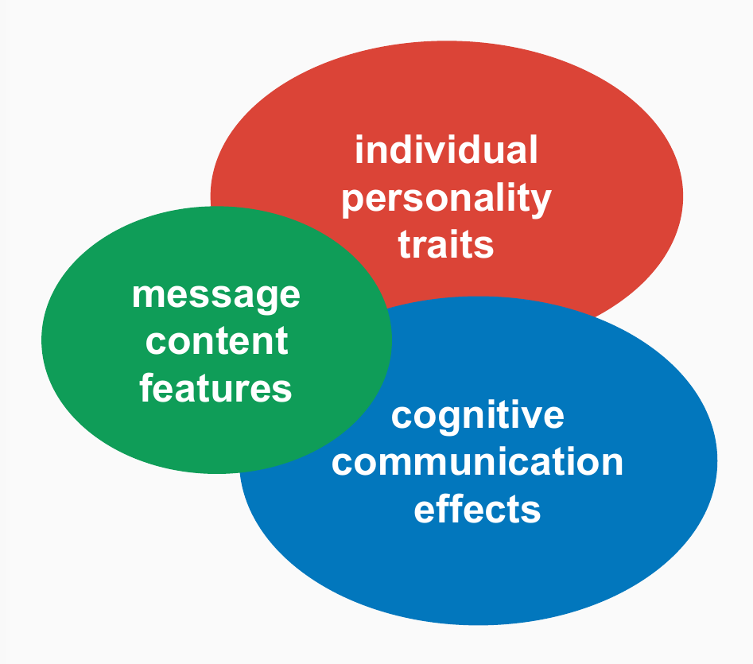

## Detection, Indicators

- Track societal and political events for hybrid war signs
- Monitor media environments to detect manipulation
- Detect anomalies in data patterns using algorithms
- Use surveillance methods to track information operations
- Identify indicators of hybrid warfare in communication channels

🧐

## Targeting, Attribution

- Microtargeting: Personalized messaging to specific groups
- Psychological operations: Influencing through cognitive manipulation
- Attribution: Identifying sources of disinformation
- AI applications: Automating detection and analysis
- Fractal analysis: Studying complex patterns in communication networks

[figure not shown]

## Content Features, NLP, CV

- Named Entity Recognition: Identifying key entities in text
- Knowledge Graphs: Structuring information for understanding
- Sentiment Analysis: Gauging public opinion and emotions
- Computer Vision: Analyzing images for manipulation
- Video Analysis: Detecting fabricated content in videos

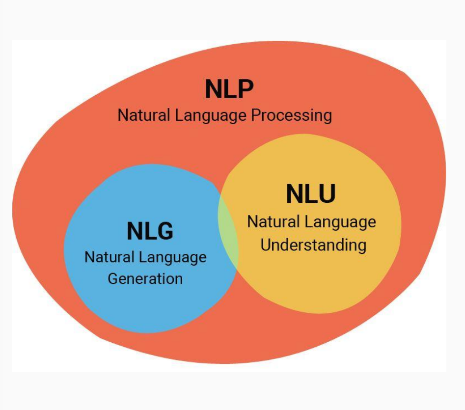

## Computational Content Analysis

- Extracting content features from text data
- Using Naive Bayes for spam-like classification
- Applying deep learning to detect complex patterns
- Inferring themes or narratives in content
- Predicting outcomes based on analysis
- [Google Colab notebook](https://colab.research.google.com/github/nils-holmberg/osm-exp/blob/main/jnb/ssk001f_methods.ipynb)

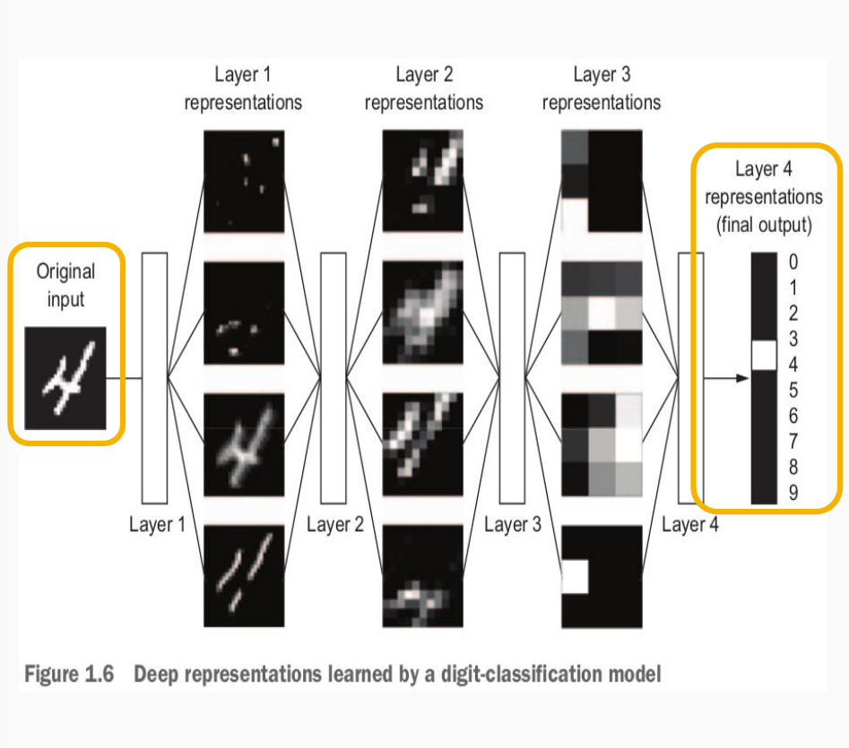

## Lecture lab overview

- Hybrid war concept
- Weaponized communications
- Targeting, attribution
- Detection, indicators
- Content features, NLP, CV
- Computational content analysis
- `CCA lab session + Break`
- Network analysis, HBMs
- Psychological defence, PDRI
- Counteraction measures
- Disinformation inoculation
- Online survey experiments
- Cognitive communication effects
- `CCE lab session`

## Network Analysis, HBMs

- Common network measures: Degree, betweenness
- Centrality and density in social networks
- Analyzing information flow through networks
- Identifying subgroups or communities
- Detecting inauthentic user behavior

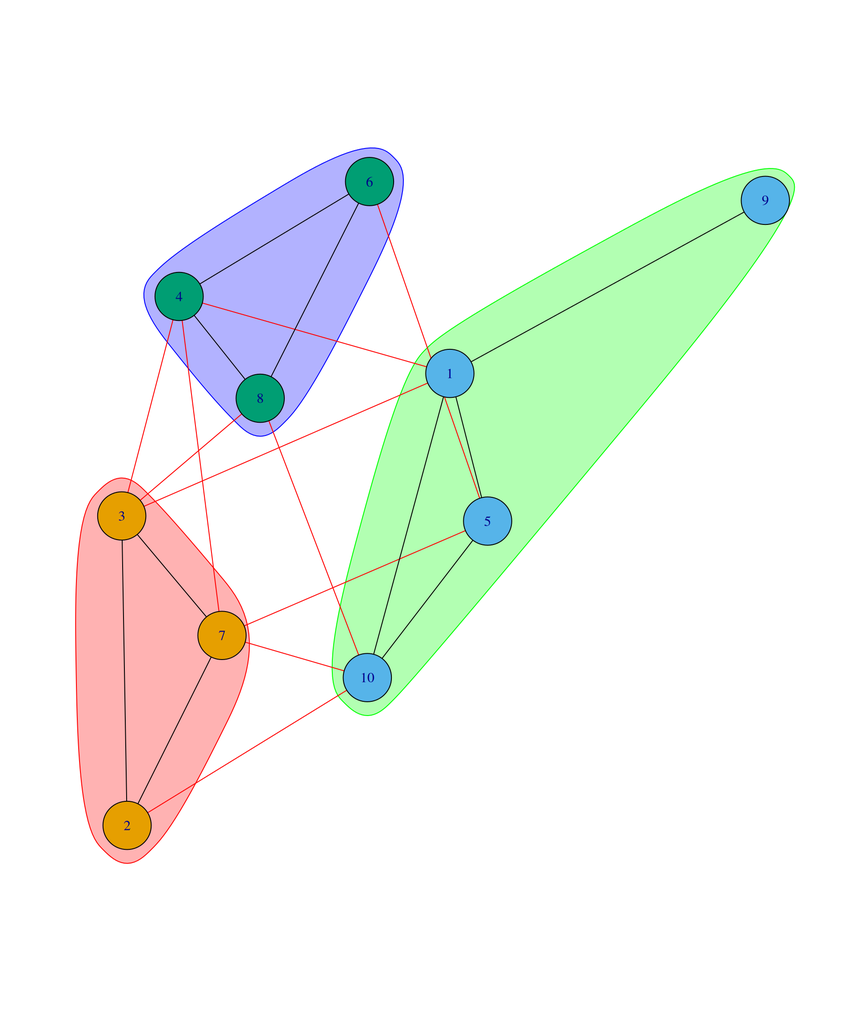

## Psychological Defence, PDRI

- Promoting media literacy to build resilience
- Implementing counteraction measures against disinformation
- Debunking adversary claims with facts
- Using inoculation to pre-empt disinformation
- Enhancing cognitive skills for critical thinking

[figure not shown]

## Disinformation Inoculation

- Raising threat awareness about disinformation
- Prebunking: Exposing debunked falsehoods
- Refuting claims with evidence
- Educating on manipulation techniques
- Promoting media literacy for truth discernment

💉

## Disinformation Inoculation Video

[video not shown]

## Online Survey Experiments

- Conducting online surveys for data collection
- Designing reliable measurement scales
- Ensuring survey validity and reliability
- Analyzing causal effects of communication
- Combining qualitative methods with surveys

[figure not shown]

## Cognitive Communication Effects

- Measuring attention to messages
- Assessing interest in content
- Evaluating behavioral actions
- Analyzing emotional responses
- Studying memory retention
- [GitHub account](https://github.com/)
- [Instructional video](https://www.youtube.com/watch?v=SmJ8x-lYl6s)

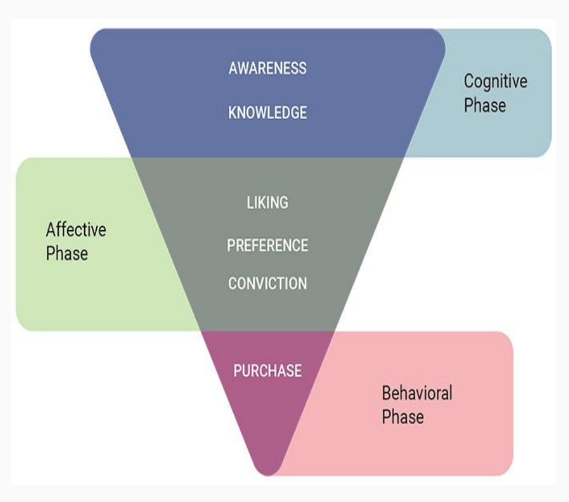

## References

Arcos, Rubén, Hanna Smith, et al. 2021. “Digital Communication and Hybrid Threats.” *Revista ICONO 14. Revista Cientı́fica de Comunicación y Tecnologı́as Emergentes* 19 (1): 1–14.

Ask, Torvald F, Ricardo G Lugo, Stefan Sütterlin, Matthew Canham, Daniel Hermansen, and Benjamin J Knox. 2023. “The UnCODE System: A Neurocentric Systems Approach for Classifying the Goals and Methods of Cognitive Warfare.” In *HFM-361 Symposium on Mitigating and Responding to Cognitive Warfare*, P12.

Batyuk, Vladimir I. 2017. “The US Concept and Practice of Hybrid Warfare.” *Strategic Analysis* 41 (5): 464–77.

Bruzzone, Agostino, Antonio Giovannetti, Marco Gotelli, Jan Hodicky, Marina Massei, Alberto De Paoli, Roberto Ferrari, and Filippo Ghisi. 2024. “Strategic Engineering to Support Decision Makers in Complex Systems: Innovative Models for Cognitive Warfare Simulation.”

Clack, Timothy, and Robert Johnson. 2021. *The World Information War: Western Resilience, Campaigning, and Cognitive Effects*. Routledge.

Compton, Joshua A, and Michael Pfau. 2005. “Inoculation Theory of Resistance to Influence at Maturity: Recent Progress in Theory Development and Application and Suggestions for Future Research.” *Annals of the International Communication Association* 29 (1): 97–146.

Danek, Magdalena. 2022. “Social Media as a Recipient and Creator of Political Actions in the Context of the Security Crisis.”

Fedushko, Solomiia, Kateryna Molodetska, and Yuriy Syerov. 2023. “Analytical Method to Improve the Decision-Making Criteria Approach in Managing Digital Social Channels.” *Heliyon* 9 (6).

Huhtinen, Aki-Mauri, Noora Kotilainen, Saara Särmä, and Mikko Streng. 2021. “Information Influence in Hybrid Environment: Reflexive Control as an Analytical Tool for Understanding Warfare in Social Media.” In *Research Anthology on Fake News, Political Warfare, and Combatting the Spread of Misinformation*, 243–59. IGI Global Scientific Publishing.

Koval, Mykhailo, Andrii Ivashchenko, Vasyl Telelym, Tobias Sæther, Dmytro Fedianovych, Tetiana Uvarova, Valerii Hordiichuk, et al. 2023. “Theoretical and Applied Aspects of the Russian-Ukrainian War: Hybrid Aggression and National Resilience.” *Monographs*.

Lim, Tong Hai, Si Cheng Yang, Kian Teck Ng, Sarah Quek, and Augustine Pang. 2025. “Seizing the Narrative in a Global Information War: Examining President Volodymyr Zelenskyy’s Media Communication Strategy.” *Journal of Communication Management*.

Lipianina-Honcharenko, Khrystyna, Yevgeniy Bodyanskiy, Nataliia Kustra, and Andrii Ivasechkо. 2024. “OLTW-TEC: Online Learning with Sliding Windows for Text Classifier Ensembles.” *Frontiers in Artificial Intelligence* 7: 1401126.

McGuire, William J. 1961. “The Effectiveness of Supportive and Refutational Defenses in Immunizing and Restoring Beliefs Against Persuasion.” *Sociometry* 24 (2): 184–97.

Melykh, Olga, and Anna Korbut. 2020. “Entertainment Media in the Context of Hybrid War in the Post-Soviet Countries: The Case of Ukraine.”

Mustonen-Ollila, Erja, Martti J Lehto, and Jukka Heikkonen. 2020. “Hybrid Warfare in Society’s Information Environment: An Empirical Analysis Using the Grounded Theory.” In *ECCWS 2020 19th European Conference on Cyber Warfare and Security*, 258. Academic Conferences; publishing limited.

Scott, JKL. 2015. “Dissuasion, Disinformation, Dissonance: Complexity and Autocritique as Tools of Information Warfare.” *Journal of Information Warfare* 14 (4): 25–42.

Wither, James K. 2023. “Hybrid Warfare Revisited: A Battle of ‘Buzzwords’.” *Connections: The Quarterly Journal* 22 (1): 7–27.

Yuskiv, Bohdan, Nataliia Karpchuk, and Sehii Khomych. 2021. “Media Reports as a Tool of Hybrid and Information Warfare (the Case of RT–Russia Today).” *Codrul Cosminolui* 1 (27): 235–58.